# Prologue

Our “Ocular Disease Recognition” project uses [this](https://www.kaggle.com/datasets/andrewmvd/ocular-disease-recognition-odir5k) Kaggle source. In this notebook we would like to focus on recognizing and classifying various ocular diseases based on eye images.  
In order to make this project more fascinating, we will include the element of storytelling  
**! Please note that all data was acquired from Kaggle and we do not own any of it. This story is purely fictional and is intended to make project reviewing more entertaining**

# A long time ago in a galaxy far, far away...

Our story revolves around the world of ophthalmology and how data science is being used to transform eye health diagnosis. In the past, diagnosing eye diseases like diabetic retinopathy, glaucoma, and cataracts required manual examination, but with the growing availability of eye image data, data scientists have emerged as powerful allies in detecting these conditions more quickly and accurately. Even in our real-world [medical applicaitons](https://pubmed.ncbi.nlm.nih.gov/33165420/), AI plays a huge role.

Now, imagine a world where AI-powered eye exams could revolutionize preventive care—by recognizing diseases in their early stages and saving millions of people from vision loss. We introduce a protagonist, Dr. Iris, an ophthalmologist who has embraced machine learning and is working on a research project to classify ocular diseases using the ODIR-5K dataset.

```python
!pip install -q kaggle
!pip install -q easyimages
!kaggle datasets download -d andrewmvd/ocular-disease-recognition-odir5k
!unzip -q /content/ocular-disease-recognition-odir5k.zip -d .
!pip install ace-tools
!pip install -q kaggle tensorflow
```

```
  Preparing metadata (setup.py) ... done
   ━━━━━━━━━━━━━━━━━━━━━━━━━━━━━━━━━━━━━━━━ 88.0/88.0 kB 4.6 MB/s eta 0:00:00
   ━━━━━━━━━━━━━━━━━━━━━━━━━━━━━━━━━━━━━━━━ 1.6/1.6 MB 22.8 MB/s eta 0:00:00
Dataset URL: https://www.kaggle.com/datasets/andrewmvd/ocular-disease-recognition-odir5k
License(s): other
Downloading ocular-disease-recognition-odir5k.zip to /content
 99% 1.61G/1.62G [00:16<00:00, 115MB/s]
100% 1.62G/1.62G [00:16<00:00, 104MB/s]
Downloading ace_tools-0.0-py3-none-any.whl (1.1 kB)
```

Dr. Iris, excited to dive into the data science journey, begins by importing the essential libraries needed to process and analyze the ocular disease dataset. She imports various tools, including pandas for data manipulation, numpy for numerical operations, seaborn and matplotlib for visualization, and statistical libraries like scipy for hypothesis testing.

```python
import numpy as np
import pandas as pd
import os
import random
import itertools
import cv2
import matplotlib.pyplot as plt
from tqdm import tqdm
import math

import tensorflow as tf
from tensorflow import keras
from tensorflow.keras import layers
from tensorflow.keras.preprocessing.image import load_img,img_to_array

from tensorflow.keras.utils import to_categorical
from tensorflow.keras.models import Model, Sequential, load_model
from tensorflow.keras.layers import Dense, Conv2D, MaxPool2D, Flatten, Reshape, Dropout
from tensorflow.keras.preprocessing import image
from tensorflow.keras.preprocessing.image import ImageDataGenerator
from tensorflow.keras.optimizers import Adam
from tensorflow.keras.callbacks import ModelCheckpoint, EarlyStopping
from tensorflow.keras.models import load_model

from keras.applications.vgg16 import VGG16
from keras.applications.vgg16 import preprocess_input

from sklearn.metrics import confusion_matrix,classification_report,accuracy_score
from sklearn.model_selection import train_test_split
from sklearn.utils import shuffle
from keras.metrics import Precision
from keras.metrics import AUC
from sklearn.metrics import roc_curve, auc


from sklearn.utils.class_weight import compute_class_weight
import shutil
from scipy import stats
from scipy.stats import chi2_contingency
import seaborn as sns
import warnings
from PIL import Image
from cv2 import Laplacian, CV_64F
from PIL import ImageFilter
```

# What is the Final Goal?

Dr. Iris, why are you doing this, may a reader ask. In roder to treat the patients efficiently, she needs to know about the "enemy" - the ocular diseases - as much as possible. The main idea is to develop a machine learning model for binary classification to distinguish between normal and cataract-affected eyes. Dr. Iris wants to do so by leveraging a Convolutional Neural Network (CNN) architecture and utilizing a pretrained Keras model as the backbone. Then she can fine-tune this pretrained model using the ODIR dataset to adapt it for the specific task of classifying eye conditions.

Dr. Iris utilized Keras's flow_from_dataframe functionality to streamline the preprocessing pipeline, enabling the generation of augmented and scaled images directly from a structured dataframe. Furthermore, she applied various preprocessing parameters to adjust and enhance the images, ensuring the input data is optimized for training. By combining the feature extraction power of CNNs with transfer learning and robust preprocessing techniques, Dr. Iris hopes that this project will deliver an accurate and efficient solution for binary classification of eye conditions.

# Tabular Data Exploration

## Loading Tabular Data

Dr. Iris is working with a large collection of eye images labeled with various ocular diseases. Her goal is to train a machine learning model that can diagnose diseases by analyzing the visual features of these eye images.

The overall dataset includes:

1. Images of the fundus (back part of the eye) that can show signs of disease.
2. Labels such as Normal, Diabetes, Glaucoma, and more.

Dr. Iris will work with tabular data first. She loads the patients' medical records. She has to preprocess, clean, and prepare these for modeling.

Dr. Iris suspects that she will face some challenges with denitifying hidden patterns within her data. Even asking the right questions can be tricky!

Lets set up our file paths and take a look at some of the the data we have right now:

```python
image_dir = '/content/preprocessed_images'
csv_dir = '/content/full_df.csv'

df = pd.read_csv(csv_dir)
df.head()
```

|  | ID | Patient Age | Patient Sex | Left-Fundus | Right-Fundus | Left-Diagnostic Keywords | Right-Diagnostic Keywords | N | D | G | C | A | H | M | O | filepath | labels | target | filename |
| --- | --- | --- | --- | --- | --- | --- | --- | --- | --- | --- | --- | --- | --- | --- | --- | --- | --- | --- | --- |
| 0 | 0 | 69 | Female | 0_left.jpg | 0_right.jpg | cataract | normal fundus | 0 | 0 | 0 | 1 | 0 | 0 | 0 | 0 | ../input/ocular-disease-recognition-odir5k/ODI... | ['N'] | [1, 0, 0, 0, 0, 0, 0, 0] | 0_right.jpg |
| 1 | 1 | 57 | Male | 1_left.jpg | 1_right.jpg | normal fundus | normal fundus | 1 | 0 | 0 | 0 | 0 | 0 | 0 | 0 | ../input/ocular-disease-recognition-odir5k/ODI... | ['N'] | [1, 0, 0, 0, 0, 0, 0, 0] | 1_right.jpg |
| 2 | 2 | 42 | Male | 2_left.jpg | 2_right.jpg | laser spot，moderate non proliferative retinopathy | moderate non proliferative retinopathy | 0 | 1 | 0 | 0 | 0 | 0 | 0 | 1 | ../input/ocular-disease-recognition-odir5k/ODI... | ['D'] | [0, 1, 0, 0, 0, 0, 0, 0] | 2_right.jpg |
| 3 | 4 | 53 | Male | 4_left.jpg | 4_right.jpg | macular epiretinal membrane | mild nonproliferative retinopathy | 0 | 1 | 0 | 0 | 0 | 0 | 0 | 1 | ../input/ocular-disease-recognition-odir5k/ODI... | ['D'] | [0, 1, 0, 0, 0, 0, 0, 0] | 4_right.jpg |
| 4 | 5 | 50 | Female | 5_left.jpg | 5_right.jpg | moderate non proliferative retinopathy | moderate non proliferative retinopathy | 0 | 1 | 0 | 0 | 0 | 0 | 0 | 0 | ../input/ocular-disease-recognition-odir5k/ODI... | ['D'] | [0, 1, 0, 0, 0, 0, 0, 0] | 5_right.jpg |

Dr. Iris, has a first glimpse of the medical records she's working with, and decides to take a look at the first few entries of the dataset.

As the table loads on her screen, she begins to understand the basic layout: each row represents a patient, and the columns contain information like their age, sex, and diagnostic results for various ocular diseases. In these records she also notices the file paths to the images of the patients' eyes, which (she suspects) will be important for training her model.

This initial view helps Dr. Iris to confirm that the dataset is properly loaded and that the columns, on which she will rely for analysis, are well-represented and organized. She feels like the dataset is ready for further exploration and cleaning

Alright, medical records are uploaded. Dr. Iris begins her analysis by taking a moment to understand the full scope of the dataset she's working with. To do this, she runs a command that gives her a comprehensive statistical overview of every column in the dataset—both numerical and categorical. What can she find there?

```python
df.describe(include='all')
```

|  | ID | Patient Age | Patient Sex | Left-Fundus | Right-Fundus | Left-Diagnostic Keywords | Right-Diagnostic Keywords | N | D | G | C | A | H | M | O | filepath | labels | target | filename |
| --- | --- | --- | --- | --- | --- | --- | --- | --- | --- | --- | --- | --- | --- | --- | --- | --- | --- | --- | --- |
| count | 6392.000000 | 6392.000000 | 6392 | 6392 | 6392 | 6392 | 6392 | 6392.000000 | 6392.000000 | 6392.000000 | 6392.000000 | 6392.000000 | 6392.000000 | 6392.000000 | 6392.000000 | 6392 | 6392 | 6392 | 6392 |
| unique | NaN | NaN | 2 | 3358 | 3358 | 196 | 205 | NaN | NaN | NaN | NaN | NaN | NaN | NaN | NaN | 6392 | 8 | 8 | 6392 |
| top | NaN | NaN | Male | 0_left.jpg | 0_right.jpg | normal fundus | normal fundus | NaN | NaN | NaN | NaN | NaN | NaN | NaN | NaN | ../input/ocular-disease-recognition-odir5k/ODI... | ['N'] | [1, 0, 0, 0, 0, 0, 0, 0] | 0_right.jpg |
| freq | NaN | NaN | 3424 | 2 | 2 | 2796 | 2705 | NaN | NaN | NaN | NaN | NaN | NaN | NaN | NaN | 1 | 2873 | 2873 | 1 |
| mean | 2271.150814 | 57.857947 | NaN | NaN | NaN | NaN | NaN | 0.328692 | 0.332134 | 0.062109 | 0.062891 | 0.049906 | 0.031758 | 0.047872 | 0.248436 | NaN | NaN | NaN | NaN |
| std | 1417.559018 | 11.727737 | NaN | NaN | NaN | NaN | NaN | 0.469775 | 0.471016 | 0.241372 | 0.242786 | 0.217768 | 0.175370 | 0.213513 | 0.432139 | NaN | NaN | NaN | NaN |
| min | 0.000000 | 1.000000 | NaN | NaN | NaN | NaN | NaN | 0.000000 | 0.000000 | 0.000000 | 0.000000 | 0.000000 | 0.000000 | 0.000000 | 0.000000 | NaN | NaN | NaN | NaN |
| 25% | 920.750000 | 51.000000 | NaN | NaN | NaN | NaN | NaN | 0.000000 | 0.000000 | 0.000000 | 0.000000 | 0.000000 | 0.000000 | 0.000000 | 0.000000 | NaN | NaN | NaN | NaN |
| 50% | 2419.500000 | 59.000000 | NaN | NaN | NaN | NaN | NaN | 0.000000 | 0.000000 | 0.000000 | 0.000000 | 0.000000 | 0.000000 | 0.000000 | 0.000000 | NaN | NaN | NaN | NaN |
| 75% | 3294.000000 | 66.000000 | NaN | NaN | NaN | NaN | NaN | 1.000000 | 1.000000 | 0.000000 | 0.000000 | 0.000000 | 0.000000 | 0.000000 | 0.000000 | NaN | NaN | NaN | NaN |
| max | 4784.000000 | 91.000000 | NaN | NaN | NaN | NaN | NaN | 1.000000 | 1.000000 | 1.000000 | 1.000000 | 1.000000 | 1.000000 | 1.000000 | 1.000000 | NaN | NaN | NaN | NaN |

As the results come in, she examines the output, which reveals a lot more than just averages and counts. The summary table shows her:

- Mean, median, and standard deviation for the numerical fields like Patient's Age
- The most common category values for fields such as gender and disease type, helping her to quickly identify which diseases dominate the dataset. • Unique counts for categorical data, revealing any unexpected variety or even potential data entry errors.

This step helps Dr. Iris quickly get a sense of the range of Patient's Sex, their distributions, and any outliers or anomalies that might need further attention.

With this knowledge in hand, she's more confident in how she should proceed with deeper analysis and model building.

## Organizing and Converting

Dr. Iris quickly checks the data types of each column. She confirms that Patient's Age is an integer, suitable for analysis, while Diagnostic Keywords for left and right eyes are objects.

She notes that she has to convert categorical columns later for optimization. Like Patient's Sex can be converted to a integers

```python
df.dtypes
```

|  | 0 |
| --- | --- |
| ID | int64 |
| Patient Age | int64 |
| Patient Sex | object |
| Left-Fundus | object |
| Right-Fundus | object |
| Left-Diagnostic Keywords | object |
| Right-Diagnostic Keywords | object |
| N | int64 |
| D | int64 |
| G | int64 |
| C | int64 |
| A | int64 |
| H | int64 |
| M | int64 |
| O | int64 |
| filepath | object |
| labels | object |
| target | object |
| filename | object |

**dtype:** object

Dr. Iris decides to make the dataset more readable by renaming the cryptic column labels. She changes abbreviations like N to “Normal” and D to “Diabetes,” making it easier to understand what each column represents at a glance. Not only this improves clarity for her analysis, but also ensures that anyone else working with the dataset can immediately recognize which column corresponds to each ocular condition

```python
# renaming columns in the DataFrame to make them more readable
df = df.rename(columns={
    'N': 'Normal',
    'D': 'Diabetes',
    'G': 'Glaucoma',
    'C': 'Cataract',
    'A': 'Age Degeneration',
    'H': 'Hypertension',
    'M': 'Myopia',
    'O': 'Other'
})
```

Dr. Iris prepares her dataset for machine learning by converting the Patient's Sex column into a numerical format where female is 1 and male is 0. This will simplify the categorical data into binary values.

Why do this? To allow the models to process gender information effectively, ensuring that the sex of the patient can be used as a feature without causing any problems during training

```python
df['Patient Sex'] = df['Patient Sex'].map({'Female': 1, 'Male': 0})
```

Dr. Iris wants to understand how balanced the dataset is across different diseases. She sums the columns representing each health condition. By calculating the percentage of each class, she quickly identifies whether any disease type is over- or under-represented

The results show that **Diabetes**, **Normal**, and **Other conditions** are overrepresented comparing to other diseases.

```python
# calculating the distribution of each health class by summing the respective columns
class_distribution = df[['Normal', 'Diabetes', 'Glaucoma', 'Cataract', 'Age Degeneration', 'Hypertension', 'Myopia', 'Other']].sum()
total_samples = len(df) # total number of samples for reference

class_distribution_percentage = (class_distribution / total_samples) * 100 # percentage distribution for each class

class_balance_df = pd.DataFrame({       # creating a DataFrame for easier analysis
    'Class Count': class_distribution,
    'Percentage of Total (%)': class_distribution_percentage
})
print("Health Class Distribution Analysis:")
class_balance_df
```

```
Health Class Distribution Analysis:
```

|  | Class Count | Percentage of Total (%) |
| --- | --- | --- |
| Normal | 2101 | 32.869212 |
| Diabetes | 2123 | 33.213392 |
| Glaucoma | 397 | 6.210889 |
| Cataract | 402 | 6.289111 |
| Age Degeneration | 319 | 4.990613 |
| Hypertension | 203 | 3.175845 |
| Myopia | 306 | 4.787234 |
| Other | 1588 | 24.843554 |

From the previous look at the medical records, Dr. Iris knows that some diseases, like **Diabetes**, are more common than others. This could lead to a biased model. So she calculates class weights for each health condition.

First, she identifies the most dominant disease for each patient by finding the column with the highest value in their diagnostic data.

Next, she assigns higher weights to under-represented classes, like **Cataract**, ensuring that the model will pay more attention to rarer diseases

```python
y = df[['Normal', 'Diabetes', 'Glaucoma', 'Cataract', 'Age Degeneration', 'Hypertension', 'Myopia', 'Other']].idxmax(axis=1)

class_weights = compute_class_weight( # class weights based on the updated target variable
    class_weight='balanced',
    classes=np.unique(y),
    y=y
)

class_weight_dict = dict(zip(np.unique(y), class_weights)) # mapping them to the corresponding disease
class_weight_dict
```

```
{'Age Degeneration': 2.99250936329588,
 'Cataract': 2.481366459627329,
 'Diabetes': 0.3763542157324541,
 'Glaucoma': 2.343108504398827,
 'Hypertension': 9.183908045977011,
 'Myopia': 3.1089494163424125,
 'Normal': 0.3802950975725845,
 'Other': 0.8937360178970917}
```

## Handling Missing Data

Dr. Iris runs a quick check for missing values in her dataset by calculating the total number of **NaN** (Not a Number) and **null** values across all columns. This step helps her identify any gaps in the data that need to be addressed before proceeding with analysis.

This is interesting and rare, medical records do not contain any missing values!

```python
df.isna().sum() + df.isnull().sum()
```

|  | 0 |
| --- | --- |
| ID | 0 |
| Patient Age | 0 |
| Patient Sex | 0 |
| Left-Fundus | 0 |
| Right-Fundus | 0 |
| Left-Diagnostic Keywords | 0 |
| Right-Diagnostic Keywords | 0 |
| Normal | 0 |
| Diabetes | 0 |
| Glaucoma | 0 |
| Cataract | 0 |
| Age Degeneration | 0 |
| Hypertension | 0 |
| Myopia | 0 |
| Other | 0 |
| filepath | 0 |
| labels | 0 |
| target | 0 |
| filename | 0 |

**dtype:** int64

Every column is fully populated, so she doesn't have to spend time on imputation or data cleaning for missing values. With this solid foundation, she can proceed directly to deeper analysis and model building. But does she need all these data points?

## Visualization

Dr. Iris wants to understand the **distribution of labels** in the dataset. Because she alreaady knows about diseases' imbalance, she reviews the count for each label to understand the **balance of the dataset**

```python
df['labels'].value_counts()
```

| labels | count |
| --- | --- |
| ['N'] | 2873 |
| ['D'] | 1608 |
| ['O'] | 708 |
| ['C'] | 293 |
| ['G'] | 284 |
| ['A'] | 266 |
| ['M'] | 232 |
| ['H'] | 128 |

**dtype:** int64

Dr. Iris decides to visualize the **distribution of the labels** in her dataset using a pie chart to quickly assess how evenly distributed the conditions are. Thsis pie chart provides an intuitive snapshot of the dataset and gives her a clear understanding of the proportional representation of each disease.

As seen in the tabular form, a bit less than half of the patients are healthy with "N" dominating the pie chart. But nearly a quarter of the chart shows "D", which stands for **Diabetes**

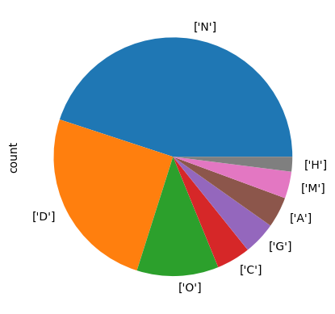

```python
df['labels'].value_counts().plot.pie()
```

Dr. Iris creates another pie chart to visualize the distribution of **Patient Sex** in the dataset. By plotting the counts of males and females, she quickly sees that the dataset is balanced.

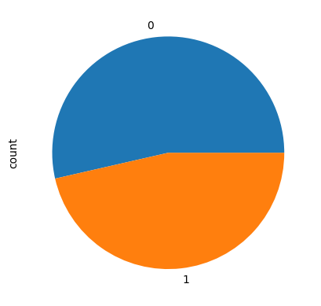

```python
df['Patient Sex'].value_counts().plot.pie()
```

Dr. Iris now decides to explore the age distribution of patients. She visualizes the spread of **Patient Age** to understand how different age groups (including information about patient sex) are represented.

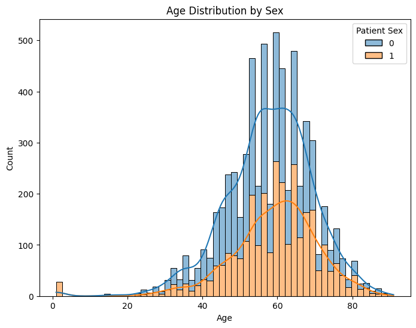

```python
plt.figure(figsize=(8, 6))
sns.histplot(data=df, x='Patient Age', hue='Patient Sex', multiple="stack", kde=True)
plt.title('Age Distribution by Sex')
plt.xlabel('Age')
plt.ylabel('Count')
plt.show()
```

The plot looks more or less normally distributed and skewed towards older ages. Dr. Iris notices some suspicious "young" patients that look like outliers. She wants to have a closer look at this:

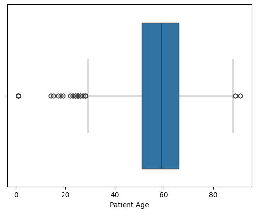

```python
sns.boxplot(data=df, x='Patient Age');
```

Indeed! Dr. Iris notices that, although there are a couple "older" outliers, the majority are around 20 or even younger.

Dr. Iris wants to go deeper into the relationships between different ocular conditions by creating a **correlation heatmap**.

The heatmap uses a color gradient to display the strength of these correlations. A value close to **1** indicates a strong positive correlation, meaning those diseases tend to occur together, while a value close to **-1** suggests a negative correlation, meaning they rarely appear together

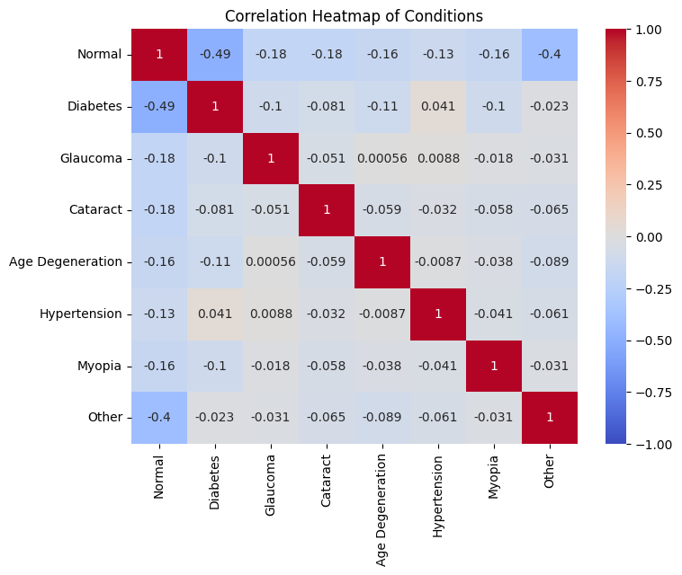

```python
# Heatmap of diseases (in general)
label_columns = ['Normal', 'Diabetes', 'Glaucoma', 'Cataract', 'Age Degeneration', 'Hypertension', 'Myopia', 'Other']
plt.figure(figsize=(8, 6))
correlation_matrix = df[label_columns].corr()
sns.heatmap(correlation_matrix, annot=True, cmap='coolwarm', vmin=-1, vmax=1)
plt.title('Correlation Heatmap of Conditions')
plt.show()
```

## Outliers

Dr. Iris now is interested in identifying **outliers**.

She starts with patient age data. To do this, she calculates the **Interquartile Range (IQR)**, which is the difference between the **first (Q1)** and **third quartile (Q3)** of the age distribution.

Based on the results, she found that the **lower bound** for potential outliers is **28.5 years** and the **upper bound** is **88.5 years**.

This means that any patients younger than 28.5 or older than 88.5 are considered **outliers** based on the age distribution.

```python
Q1 = df['Patient Age'].quantile(0.25)
Q3 = df['Patient Age'].quantile(0.75)
IQR = Q3 - Q1
print(f'{Q1 - 1.5*IQR} {Q3 + 1.5*IQR}')
```

```
28.5 88.5
```

Dr. Iris wants to calculate the proportion of patients who fall outside the age bounds that she found above. For this, she calculates the percentage of patients who are younger than 28.5 and those older than 88.5

```python
print(len(df[df['Patient Age'] < 28.5]) / len(df) * 100) # percentage of patients who are younger than 28.5
print(len(df[df['Patient Age'] > 88.5]) / len(df) * 100) # percentage of patients who are older than 88.5
```

```
1.2672090112640801
0.09386733416770963
```

Since the outliers make up less than 5% of the entire dataset, Dr. Iris decides it is safe to exclude them from the training data. This will reduce the chance of skewed results caused by a small, extreme portion of the dataset.

She now resets the index of her DataFrame to ensure the dataset has a continuous index to avoid any confusion caused by the original indexing

```python
df.reset_index(drop=True, inplace=True)
```

## Feature Engineering

### Categories for severity based on diagnostic keywords for left and right eye

Dr. Iris decides to assign the severity levels to each patient's left and right eyes based on diagnostic keywords. She categorizes conditions as normal, mild, moderate, or severe, and stores these in the columns left-diagnostic-category and right-diagnostic-category. If no severity is found, it is marked as none

```python
diagnostic_keyword_features = ['Left-Diagnostic Keywords', 'Right-Diagnostic Keywords']
diagnostic_severity_features = ['left-diagnostic-category', 'right-diagnostic-category']
df['left-diagnostic-category'] = 'none'
df['right-diagnostic-category'] = 'none'
for keyword_feature, severity in zip(diagnostic_keyword_features, diagnostic_severity_features):
  print(keyword_feature)
  no_severity_count = 0
  normal_count = 0
  mild_count = 0
  moderate_count = 0
  severe_count = 0
  for i in range(len(df)):
    keyword = df.loc[i, keyword_feature]
    # print(i, keyword)
    if 'normal fundus' in keyword:
      df.loc[i, severity] = 'normal'
      normal_count += 1
    elif 'mild' in keyword:
      df.loc[i, severity] = 'mild'
      mild_count += 1
    elif 'moderate' in keyword:
      df.loc[i, severity] = 'moderate'
      moderate_count += 1
    elif 'severe' in keyword:
      df.loc[i, severity] = 'severe'
      severe_count += 1
    else:
      df.loc[i, severity] = 'none'
      no_severity_count += 1

  print(f'normal: {normal_count}; mild: {mild_count}; moderate: {moderate_count}; severe: {severe_count}; none: {no_severity_count}')
```

```
Left-Diagnostic Keywords
normal: 2898; mild: 517; moderate: 917; severe: 169; none: 1891
Right-Diagnostic Keywords
normal: 2777; mild: 540; moderate: 960; severe: 162; none: 1953
```

### Categorizing the 'Patient Age' variable

Dr. Iris decides to bin Patient Age. She uses Sturge's rule to determine the optimal number of bins.

This method helps her create a well-balanced histogram that effectively represents the data without oversimplifying or overcomplicating the visualization

```python
n = df['Patient Age'].shape[0]
# by Sturge's rule
nbins = int(1 + 3.322*np.log(n))
nbins
```

```
30
```

Dr. Iris checks the **minimum age** is 1 and the **maximum age** is 91, giving her the range of interest.

Using the number of bins she calculated before, she determines the bin width

```python
print(f'minimum age is {df["Patient Age"].min()}, maximum age is {df["Patient Age"].max()}')
start = 28
end = 90
bin_width = int((end - start) / nbins)
bin_width
```

```
minimum age is 1, maximum age is 91
```

```
2
```

```python
# We'll adjust the range
start = 28
end = 90
bin_width = int((end - start) / nbins)
bin_width
```

```
2
```

Dr. Iris finishes the binning process by calculating the bin edges. This gives her an evenly spaced set of bins that will be used to visualize the distribution of patient ages

```python
bins = [start + i*bin_width for i in range(nbins+2)]
bins = [i for i in range(start, end+bin_width, bin_width)]
print(bins)
```

```
[28, 30, 32, 34, 36, 38, 40, 42, 44, 46, 48, 50, 52, 54, 56, 58, 60, 62, 64, 66, 68, 70, 72, 74, 76, 78, 80, 82, 84, 86, 88, 90]
```

### Age Outliers Removal

To ensure that her analysis focuses on the adult population and eliminates potential outliers or data entry errors, Dr. Iris decided to excluded all patients under the age of 20. This step allows her to focus on the age range that is most relevant to common ocular diseases

```
Original dataset size: 6392
Dataset size after removing people under 20: 6354
Number of people under 20 removed: 38
```

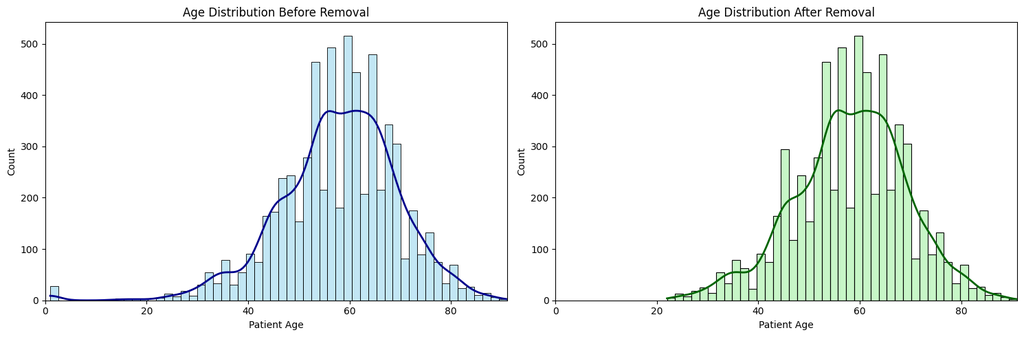

```
Summary statistics of cleaned age data:
count    6354.000000
mean       58.173434
std        11.014985
min        22.000000
25%        51.000000
50%        59.000000
75%        66.000000
max        91.000000
Name: Patient Age, dtype: float64
```

```python
def age_outliers(df, age_column='Patient Age'):
    print(f"Original dataset size: {len(df)}")
    under_20 = df[df[age_column] < 20]
    df_clean = df[df[age_column] >= 20]

    print(f"Dataset size after removing people under 20: {len(df_clean)}")
    print(f"Number of people under 20 removed: {len(under_20)}")

    fig, (ax1, ax2) = plt.subplots(1, 2, figsize=(15, 5))
    sns.histplot(df[age_column], kde=True, ax=ax1, color='skyblue')
    ax1.lines[0].set_color('darkblue')
    ax1.lines[0].set_linewidth(2)
    ax1.set_title("Age Distribution Before Removal")
    ax1.set_xlim(0, df[age_column].max())
    sns.histplot(df_clean[age_column], kde=True, ax=ax2, color='lightgreen')
    ax2.lines[0].set_color('darkgreen')
    ax2.lines[0].set_linewidth(2)
    ax2.set_title("Age Distribution After Removal")
    ax2.set_xlim(0, df[age_column].max())
    plt.tight_layout()
    plt.show()
    return df_clean, under_20

cleaned_df, removed_data = age_outliers(df)
print("\nSummary statistics of cleaned age data:")
print(cleaned_df['Patient Age'].describe())
cleaned_df = cleaned_df.reset_index(drop=True)
```

Dr. Iris reviews the summary statistics of the cleaned dataset after removing patients under 20 years old:

- **Count**: 6,354 patients remain, which is good
- **Mean Age**: around 58 years, which indicates that most patients are middle-aged or older
- **Standard Deviation**: 11.01, which shows moderate variability in age
- **Age Range**: The youngest patient is now 22, and the oldest is 91.
- **Quartiles**: 25% of patients are younger than 51, 50% (median) are younger than 59, and 75% are younger than 66.

These statistics confirm that the dataset is now focused on a more relevant age group, aligning with the goals of her analysis

Dr. Iris now decided to reepeat her analysis of the diseases' distribution in the cleaned dataset. She visualizes this using a pie chart to illustrate the proportion of each disease in the dataset, labeling the chart with percentages for easy interpretation

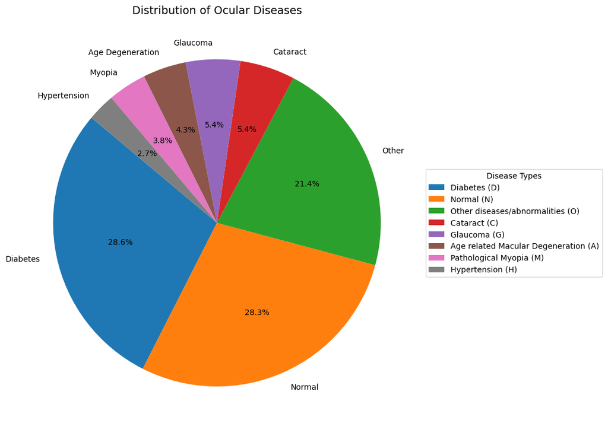

```
Distribution of Diseases:
Diabetes (D): 2119
Normal (N): 2095
Other diseases/abnormalities (O): 1586
Cataract (C): 402
Glaucoma (G): 397
Age related Macular Degeneration (A): 317
Pathological Myopia (M): 281
Hypertension (H): 203
```

```python
disease_counts = cleaned_df[['Normal', 'Diabetes', 'Glaucoma', 'Cataract', 'Age Degeneration', 'Hypertension', 'Myopia', 'Other']].sum().sort_values(ascending=False)
disease_labels = {
    'Normal': 'Normal (N)',
    'Diabetes': 'Diabetes (D)',
    'Glaucoma': 'Glaucoma (G)',
    'Cataract': 'Cataract (C)',
    'Age Degeneration': 'Age related Macular Degeneration (A)',
    'Hypertension': 'Hypertension (H)',
    'Myopia': 'Pathological Myopia (M)',
    'Other': 'Other diseases/abnormalities (O)'
}
fig, ax = plt.subplots(figsize=(10, 8))
plt.pie(disease_counts.values, labels=disease_counts.index, autopct='%1.1f%%', startangle=140)
plt.legend([disease_labels[disease] for disease in disease_counts.index], title="Disease Types", loc="center left", bbox_to_anchor=(1, 0, 0.5, 1))

plt.title('Distribution of Ocular Diseases', fontsize=14, y=1)
plt.tight_layout()
plt.show()

total_patients = len(cleaned_df)
print("Distribution of Diseases:")
for disease, count in disease_counts.items():
    print(f"{disease_labels[disease]}: {count}")
```

Dr.Iris finds the top conditions: **Diabetes** (2,119 cases) and **Normal** (2,095 cases). Other significant findings include 1,586 cases of **Other diseases/abnormalities**, which are not explicitly listed.

This concludes tabular data exploration

# Images Exploration

With the tabular exploration finished, Dr. Iris shifts her focus to the next important part of the project: **image exploration**.

She prepares to dive into the eye images associated with each patient, knowing that visual data will play a pivotal role in training her model to detect and classify ocular diseases based on these diagnostic images

## Loading Images

Dr. Iris begins by loading the directories containing the **training** and **testing images** for her project. These images, paired with the diagnostic labels from the tabular data, will be the foundation for training a machine learning model that can **predict ocular diseases** based on eye scans

```python
train_dir = '/content/ODIR-5K/ODIR-5K/Training Images' # directory for training images
test_dir = '/content/ODIR-5K/ODIR-5K/Testing Images'   # directory for testing images

train_files = os.listdir(train_dir)                    # these will be our training images
test_files = os.listdir(test_dir)                      # these will be our testing images
```

She constructs the full path to the first image in the training dataset and visualizes it.

With this successful preview, Dr. Iris is ready to start pre-processing the entire dataset of images, preparing them for training her model

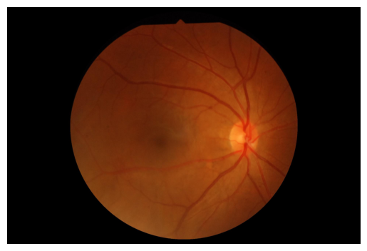

```python
# Dr. Iris picks at some random image from the dataset
image_path = os.path.join(train_dir, train_files[0])
img = Image.open(image_path)
img.show()

plt.imshow(img)
plt.axis('off')
plt.show()
```

Dr. Iris now wants to load all of the training and testing images into memory to systematically load and inspect the images that will be used to train and evaluate her machine learning model.

```python
# list of training images
train_images = []
for file in train_files:
    image_path = os.path.join(train_dir, file)
    img = Image.open(image_path)
```

```python
# creating a list of test images
test_path = os.path.join(test_dir, test_files[0])
img = Image.open(test_path)
img.show()

test_images = []
for file in test_files:
    test_path = os.path.join(test_dir, file)
    img = Image.open(test_path)
```

## Initial Exploration

Dr. Iris quickly checks the columns of her cleaned dataset and inspects the first few entries to ensure everything is properly formatted. This step gets a better understanding on what the schema of the datasets look like

```python
print(cleaned_df.columns)
# inspect the labels column to check the format
cleaned_df['labels'].head()
```

```
Index(['ID', 'Patient Age', 'Patient Sex', 'Left-Fundus', 'Right-Fundus',
       'Left-Diagnostic Keywords', 'Right-Diagnostic Keywords', 'Normal',
       'Diabetes', 'Glaucoma', 'Cataract', 'Age Degeneration', 'Hypertension',
       'Myopia', 'Other', 'filepath', 'labels', 'target', 'filename',
       'left-diagnostic-category', 'right-diagnostic-category'],
      dtype='object')
```

|  | labels |
| --- | --- |
| 0 | ['N'] |
| 1 | ['N'] |
| 2 | ['D'] |
| 3 | ['D'] |
| 4 | ['D'] |

**dtype:** object

Dr. Iris decides to count the occurrences of each disease, from which she quickly gets an overview of how often each condition appears in the dataset. She visualizes the 8 columns that correspond to each disease.

Next, she will use the labels column to check for inconsistencies between patient data and image data

```
labels
N    2864
D    1605
O     708
C     293
G     284
A     264
M     208
H     128
Name: count, dtype: int64
```

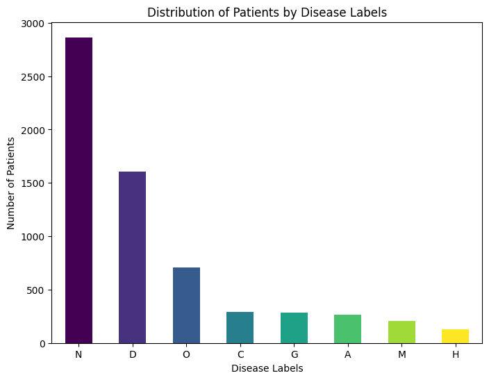

```python
# split the labels column into seperate diseases
cleaned_df['labels'] = cleaned_df['labels'].astype(str).apply(lambda x: eval(x) if x.startswith('[') and x.endswith(']') else x)

# expand the labels column so that each disease gets its own row
df_exploded = cleaned_df.explode('labels')

# count the occurrences of each disease
disease_counts = df_exploded['labels'].value_counts()

# display the frequency of each disease
print(disease_counts)

# plot the distribution of each disease
plt.figure(figsize=(8, 6))
disease_counts.plot(kind='bar', color=plt.cm.viridis(np.linspace(0, 1, len(disease_counts))))
plt.title('Distribution of Patients by Disease Labels')
plt.xlabel('Disease Labels')
plt.ylabel('Number of Patients')
plt.xticks(rotation=0)
plt.show()
```

Dr. Iris again observes from the graph that **Normal (N)** cases dominate the dataset, while **Diabetes (D)** is the most frequent disease. This imbalance suggests that the model might be biased towards predicting normal eyes, making it less effective at identifying less common diseases like **Pathological Myopia (M)** or **Hypertension (H)**. To address this, Dr. Iris considers future strategies like **resampling** or **class weighting** during model training to ensure better generalization

Next, Dr. Iris previews a few of the training images to visually inspect their quality and content

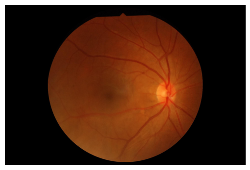

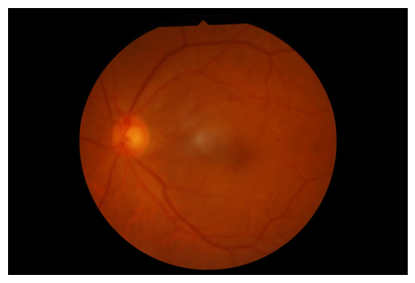

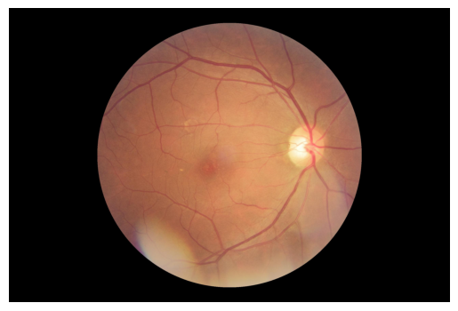

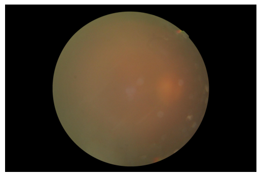

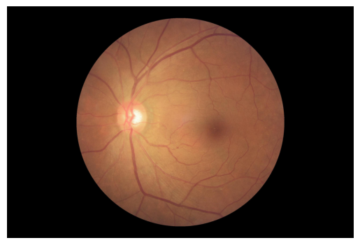

```python
for i in range(0,5):
  image_path = os.path.join(train_dir, train_files[i])
  img = Image.open(image_path)
  img.show()

  plt.imshow(img)
  plt.axis('off')
  plt.show()
```

Dr. Iris notices from the first 5 images that the **image sizes** vary. This prompts her to investigate the size consistency of the entire dataset and visualize the variations.

Next, she wwants to analyze and visualize the **image sizes** across the dataset to identify how much variation there is and determine if resizing or standardizing the images is necessary for effective model training

## Checking Size Inconsistencies

Dr. Iris creates a function to check and record the **sizes of the images** in both the training and testing directories. After gathering the image dimensions, she visualizes the variation in sizes using two types of plots:

1. A **scatterplot** showing the relationship between width and height, which allows her to see how the dimensions vary across the dataset.
2. Two histograms displaying the **distribution of widths** and **heights** separately, highlighting which image sizes are most common

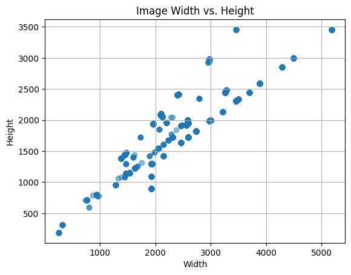

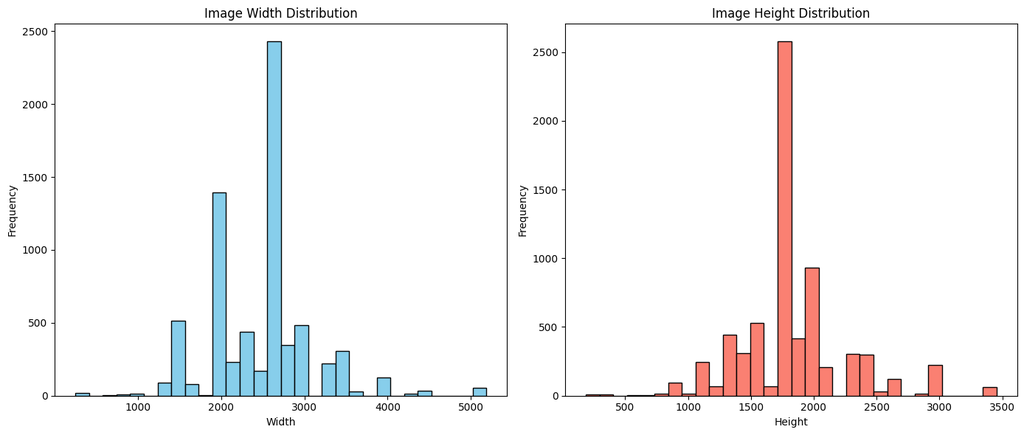

```python
# function that checks the image sizes
def check_image_sizes(dir):
    sizes = []
    for img_file in os.listdir(dir):
        img_path = os.path.join(dir, img_file)
        try:
            with Image.open(img_path) as img:
                sizes.append(img.size)
        except Exception as e:
            print(f"Error opening {img_file}: {e}")
    return sizes

# check sizes for training and testing data
train_sizes = check_image_sizes(train_dir)
test_sizes = check_image_sizes(test_dir)


# turn sizes into a df
sizes_df = pd.DataFrame(train_sizes, columns=['Width', 'Height'])

# scatterplot of width vs height
plt.scatter(sizes_df['Width'], sizes_df['Height'], alpha=0.5)
plt.title('Image Width vs. Height')
plt.xlabel('Width')
plt.ylabel('Height')
plt.grid(True)

plt.figure(figsize=(14, 6))

# width Histogram
plt.subplot(1, 2, 1)
plt.hist(sizes_df['Width'], bins=30, color='skyblue', edgecolor='black')
plt.title('Image Width Distribution')
plt.xlabel('Width')
plt.ylabel('Frequency')

# height Histogram
plt.subplot(1, 2, 2)
plt.hist(sizes_df['Height'], bins=30, color='salmon', edgecolor='black')
plt.title('Image Height Distribution')
plt.xlabel('Height')
plt.ylabel('Frequency')

plt.tight_layout()
plt.show()
```

In the scatter plot, Dr. Iris sees a clear positive correlation between the width and height of the images with larger images being proportionally scaled. However, the plots also reveal significant variation in image sizes, suggesting a potential inconsistency in image resolution, which was one of the dataset warning in Kaggle.

Next Dr. Iris takes calculatwa the **pixel size** and **aspect ratio** of each image. She uses a standard DPI (dots per inch) of 72 to estimate the total pixel count for each image and then computes the aspect ratio as the ratio of width to height.

To visualize these new insights:

1. **Pixel Size Distribution**: A histogram shows how the total pixel count varies across images, highlighting the diversity in image resolution.
2. **Aspect Ratio Distribution**: Another histogram reveals the distribution of aspect ratios, helping Dr. Iris assess whether most images are proportionally similar or if there are significant variations in shape

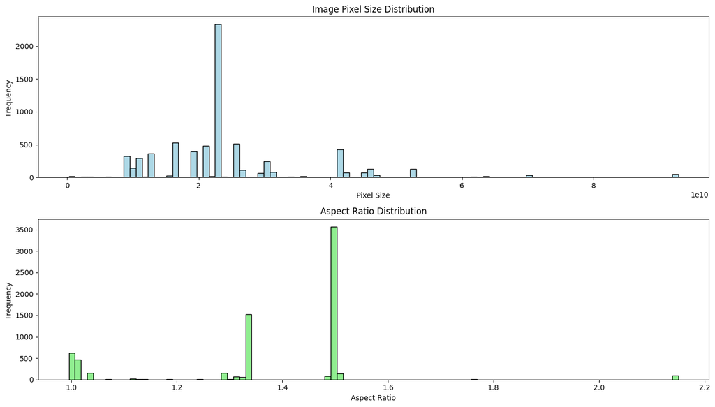

```python
DPI = 72
sizes_df['Pixel_Size'] = (sizes_df['Width'] * DPI) * (sizes_df['Height'] * DPI) # pixel size = (width * dpi) * (height * dpi)
sizes_df['Aspect_Ratio'] = sizes_df['Width'] / sizes_df['Height'] # aspect ratio = width / height

plt.figure(figsize=(14, 8))

# histogram of Pixel Size
plt.subplot(2, 1, 1)
plt.hist(sizes_df['Pixel_Size'], bins=100, color='lightblue', edgecolor='black')
plt.title('Image Pixel Size Distribution')
plt.xlabel('Pixel Size')
plt.ylabel('Frequency')

# histogram of Aspect Ratio
plt.subplot(2, 1, 2)
plt.hist(sizes_df['Aspect_Ratio'], bins=100, color='lightgreen', edgecolor='black')
plt.title('Aspect Ratio Distribution')
plt.xlabel('Aspect Ratio')
plt.ylabel('Frequency')

plt.tight_layout()
plt.show()
```

## Resizing

Dr. Iris wants to delete any existing directories before proceeding with testing or creating new ones

```python
# delete any exisiting folders (just for testing)

def delete_dir(dir):
  if os.path.exists(dir):
    shutil.rmtree(dir)
    print(f"Directory {dir} has been deleted.")
  else:
    print(f"Directory {dir} does not exist.")

resized_train_dir = '/content/resized_train_images'
```

She resizes images to a uniform size of **224x224 pixels**. This will ensurw that all images are standardized, making them consistent for model training

She first clears the resized image directory using the previously created function to delete any existing files and then creates a new directory to store the resized images

```python
def resize_img(image_path, target_size, save_dir):
    with Image.open(image_path) as img:
        resized_img = img.resize(target_size)
        resized_img.save(os.path.join(save_dir, os.path.basename(image_path)))

target_size = (224, 224)
resized_train_dir = '/content/resized_train_images'
delete_dir(resized_train_dir)
os.makedirs(resized_train_dir, exist_ok=True)

for img_file in train_files[:5]: #resize the first five training images
    img_path = os.path.join(train_dir, img_file)
    resize_img(img_path, target_size, resized_train_dir)
```

```
Directory /content/resized_train_images does not exist.
```

Dr. Iris now displays the first 5 resized images and confirms that the resizing process worked correctly. This step helps her confirm that the resizing function is working as intended and that the resized images are ready for further preprocessing or direct use in model training

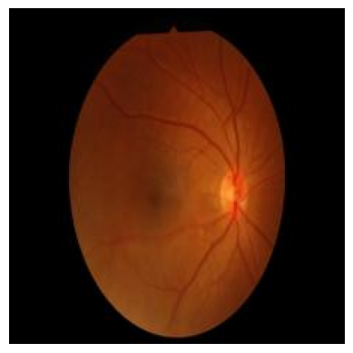

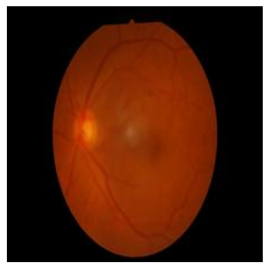

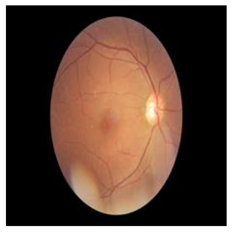

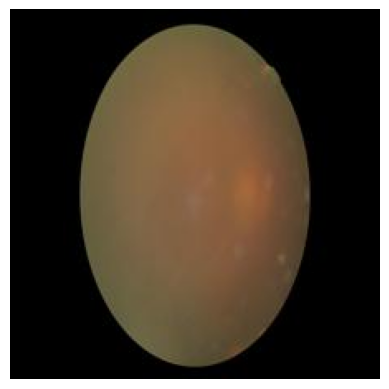

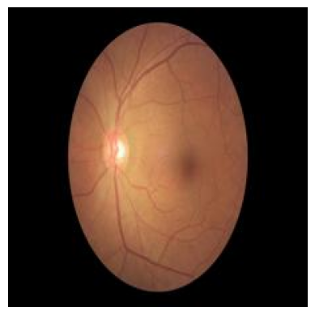

```python
# use inline to for matplotlib to render correctly
%matplotlib inline

resized_train_files = os.listdir(resized_train_dir)

for i in range(5): # display the first five resized training images
    image_path = os.path.join(resized_train_dir, resized_train_files[i])

    try:
        new_img = Image.open(image_path)
        plt.imshow(new_img)
        plt.axis('off')
        plt.show()

    except Exception as e:
        print(f"Error opening image {image_path}: {e}")
```

Dr. Iris sees that the resizing process has been successful, as each image now displays consistently at the target size of **224x224 pixels**

## Image Quality + Sharpening

Dr. Iris uses image-processing techniques like sharpening images and detecting blurred regions using methods such as Laplacian variance

```python
def is_blurry(image_path, threshold):
    with Image.open(image_path) as img:
        img_np = np.array(img.convert('L'))  # convert to grayscale for laplacian
        laplacian_var = Laplacian(img_np, CV_64F).var()
        # print(f"Laplacian variance for {os.path.basename(image_path)}: {laplacian_var}")
        return laplacian_var < threshold

blurry_images = []
blurry_count = 0

for file in resized_train_files:  # resize only the first 5 images for now
    img_path = os.path.join(resized_train_dir, file)
    if is_blurry(img_path, 100): # use threshold of 50 for blurriness
        blurry_images.append(file)
        blurry_count += 1

print("number of blurry images: ", blurry_count)
```

```
number of blurry images:  3
```

Shee sees that out of the first 5 images, some were considered blurry, so Dr. Iris decides to sharpen the images next

She creates a function that uses an **Unsharp Mask** filter to enhance the sharpness. Dr. Iris sets up a new directory, **sharpened_images**, and applies the sharpening filter only to the previously identified blurry images

```python
def sharpen(image_path, save_dir):
    with Image.open(image_path) as img:
        sharpened_img = img.filter(ImageFilter.UnsharpMask(radius=2, percent=150, threshold=3))
        sharpened_img.save(os.path.join(save_dir, os.path.basename(image_path)))


sharpened_images_dir = "/content/sharpened_images"
delete_dir(sharpened_images_dir)
os.makedirs(sharpened_images_dir, exist_ok=True)


for file in blurry_images: # sharpen only the blurry images
    img_path = os.path.join(resized_train_dir, file)
    sharpen(img_path, sharpened_images_dir)

print(f"Sharpened blurry images saved in {sharpened_images_dir}")
```

```
Directory /content/sharpened_images does not exist.
Sharpened blurry images saved in /content/sharpened_images
```

Dr. Iris visualizes the **sharpened images** by loading and displaying them from the **sharpened_images** directory. Looking at the first few images, she confirms that the sharpening process has been successful

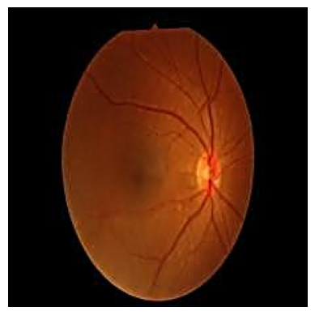

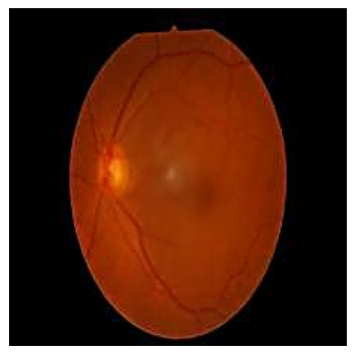

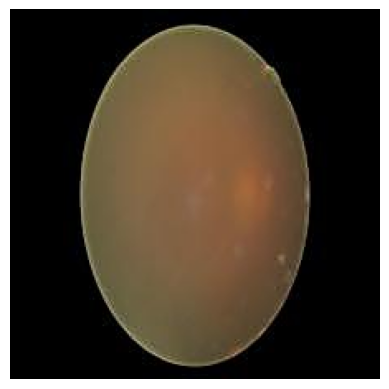

```python
sharpened_train_files = os.listdir(sharpened_images_dir)

for i in range(len(blurry_images)): # display the first five sharpened images
    image_path = os.path.join(sharpened_images_dir, sharpened_train_files[i])

    try:
        new_img = Image.open(image_path)
        plt.imshow(new_img)
        plt.axis('off')
        plt.show()

    except Exception as e:
        print(f"Error opening image {image_path}: {e}")
```

## Normalization

After sharpening blurry images, Dr. Iris adds a **normalization** step to ensure that the pixel values of all images fall within the range **[0, 1]**, which is essential for training most machine learning models.

She creates a new directory, **normalized_images**, where the processed files are saved

```python
def normalize(image_path, save_dir):
    with Image.open(image_path) as img:
        img_np = np.array(img, dtype=np.float32)
        img_normalized = img_np / 255.0  # normalize to [0, 1]

        normalized_img = Image.fromarray(np.uint8(img_normalized * 255))  # re-scale back to [0, 255] to save file
        normalized_img.save(os.path.join(save_dir, os.path.basename(image_path)))

normalized_images_dir = "/content/normalized_images"
delete_dir(normalized_images_dir)
os.makedirs(normalized_images_dir, exist_ok=True)

for file in os.listdir(resized_train_dir): # normalize resized images + sharpened images
    if file in blurry_images:
      img_path = os.path.join(sharpened_images_dir, file)
    else:
      img_path = os.path.join(resized_train_dir, file)

    normalize(img_path, normalized_images_dir)

print(f"All images have been normalized and saved in {normalized_images_dir}.")
```

```
Directory /content/normalized_images does not exist.
All images have been normalized and saved in /content/normalized_images.
```

Dr. Iris now visualizes the first five normalized images and sees that the normalization process worked alright.

This final check ensures that the normalization has been applied consistently and that the images are ready for use in the upcoming machine learning tasks

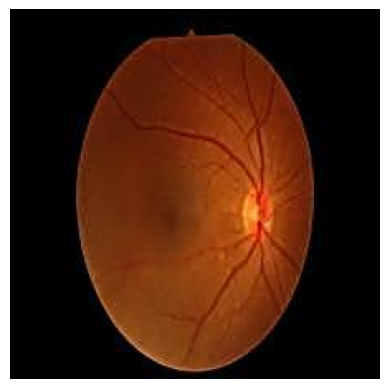

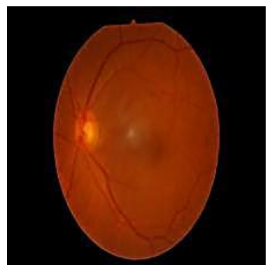

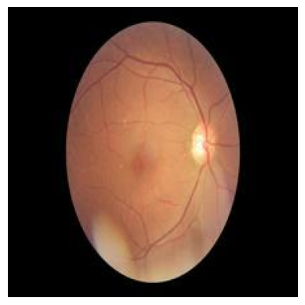

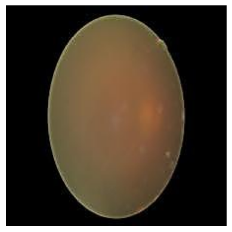

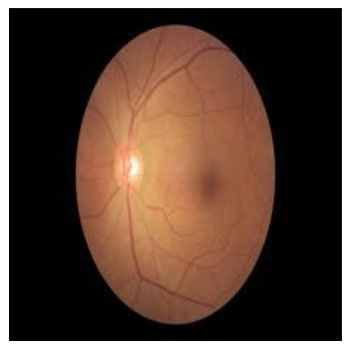

```python
normalized_train_files = os.listdir(normalized_images_dir)

for i in range(5): # display the first five sharpened images
    image_path = os.path.join(normalized_images_dir, normalized_train_files[i])

    try:
        new_img = Image.open(image_path)
        plt.imshow(new_img)
        plt.axis('off')
        plt.show()

    except Exception as e:
        print(f"Error opening image {image_path}: {e}")
```

This concludes the image exploration part, and now Dr. Iris shifts her focus to the next phase: **basic data exploration and summary statistics** of the tabular data. This will include gaining deeper insights into the structure, distribution, and characteristics of the dataset, which will guide her in preparing the data for model building and analysis

# Data Exploration and Summary Statistics

Now that Dr. Iris knows all the main statistics, distributions, and had a rough idea about inner relationship among the features, she starts asking important questions

## Question 1: How does the mean age of patients with each ocular disease compare?

She calculates the mean age for each disease category (e.g., Diabetes, Glaucoma, Cataract) to explore whether certain conditions tend to affect older or younger populations

```
            Disease   Mean Age
3          Cataract  66.467662
2          Glaucoma  62.418136
6            Myopia  61.476868
4  Age Degeneration  61.227129
7             Other  59.395334
0            Normal  56.857279
1          Diabetes  56.417650
5      Hypertension  56.142857
```

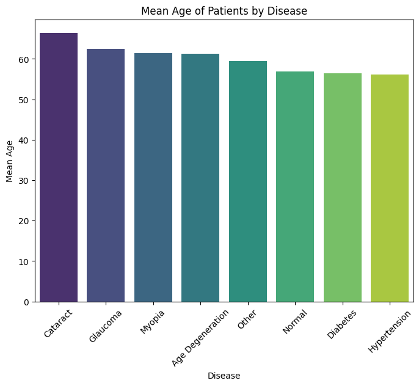

```python
# a dictionary to store mean age per disease
mean_age_per_disease = {}
disease_columns = ['Normal', 'Diabetes', 'Glaucoma', 'Cataract', 'Age Degeneration', 'Hypertension', 'Myopia', 'Other']

for disease in disease_columns:
    mean_age_per_disease[disease] = cleaned_df[cleaned_df[disease] == 1]['Patient Age'].mean()

mean_age_df = pd.DataFrame(list(mean_age_per_disease.items()), columns=['Disease', 'Mean Age'])
mean_age_df = mean_age_df.sort_values(by='Mean Age', ascending=False) # sorting by mean age for better comparison
print(mean_age_df)

# visualizing
plt.figure(figsize=(8, 6))
sns.barplot(x='Disease', y='Mean Age', data=mean_age_df, palette='viridis')
plt.title('Mean Age of Patients by Disease')
plt.xlabel('Disease')
plt.ylabel('Mean Age')
plt.xticks(rotation=45)
plt.show()
```

Dr. Iris discovers the following:

- **Cataract** has the highest mean age at **66.47 years**, followed by **Glaucoma** at **62.42 years**, which indicates that these conditions are more common in older patients
- **Age Degeneration** and **Myopia** also have relatively higher mean ages, around **61 years**
- Patients labeled as **Normal** and those diagnosed with **Diabetes** or **Hypertension** tend to be younger, with mean ages around **56 years**

These findings suggest that there are some age-related conditions like **Cataract** and **Glaucoma**, which are more prevalent in older patients, while **Diabetes** and **Hypertension** affect all populations

## Question 2: Which feature shows the highest variance, and how does that affect modeling?

Dr. Iris wants to analyze the variance of each feature, such as patient age, disease types, and other numerical or categorical variables. Features with high variance indicate a broad range of values, while low variance suggests that most of the data points are clustered around a central value.

Why may this be important?

Because high variance in certain features (e.g., age or a specific disease) could introduce instability into the model, as these features might cause the model to focus disproportionately on rare or extreme cases

```
Sorted variance (highest to lowest):
Patient Age         121.33
Patient Sex           0.25
Normal                0.22
Diabetes              0.22
Other                 0.19
Glaucoma              0.06
Cataract              0.06
Age Degeneration      0.05
Myopia                0.04
Hypertension          0.03
dtype: object
```

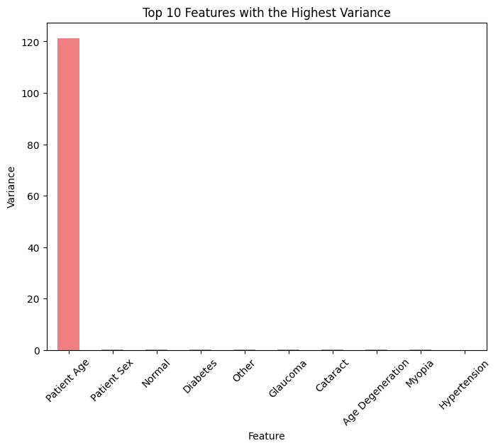

```python
def calculate_variance(df):
    df_numerical = df.drop(columns=['ID'], errors='ignore') # we don't want 'ID' here
    variance_df = df_numerical.var(numeric_only=True)       # variance for numerical features
    variance_df = variance_df.apply(lambda x: f"{x:.2f}")

    sorted_variance_df = variance_df.sort_values(ascending=False)  # soritng the variances in descending order

    print("\nSorted variance (highest to lowest):")
    print(sorted_variance_df)

    plt.figure(figsize=(8, 6)) # plotting
    sorted_variance_df.head(10).astype(float).plot(kind='bar', color='lightcoral')
    plt.title('Top 10 Features with the Highest Variance')
    plt.xlabel('Feature')
    plt.ylabel('Variance')
    plt.xticks(rotation=45)
    plt.show()


calculate_variance(cleaned_df)
```

Dr. Iris discovers the following:

1. **Patient Age** has the highest variance (121.33), which is way wider than any other feature
2. **Patient Sex** shows a low variance (0.25), which confirms the earlier conclusions that the gender distribution is more balanced, but still has some variation.
3. **Normal**, **Diabetes**, and **Other diseases** show moderate variance (around 0.19 to 0.22), while the less frequent diseases like **Glaucoma**, **Cataract**, and **Hypertension** have very low variance